# Homework 8

Spencer Tibbitts

11/21/2019

## Can a New Drug Reduce the Spread of Schistosomiasis?

Schistosomiasis (skis-tuh-soh-may’-uh-sis) is a disease in humans caused by parasitic flatworms called schistosomes (skis’-tuh-sohms). Schistosomiasis affects about 200 million people worldwide and is a serious problem in sub-Saharan Africa, South America, China, and Southeast Asia. The disease can cause death, but more commonly results in chronic and debilitating symptoms, arising primarily from the body’s immune reaction to parasite eggs lodged in the liver, spleen,and intestines.

Currently there is one drug, praziquantel (pray’-zee-kwan-tel), in common use for treatment of schistosomiasis; it is inexpensive and effective. However, many organizations are concerned about relying on a single drug to treat a serious disease that affects so many people worldwide. Drug resistance may have prompted an outbreak in the 1990s in Senegal, where cure rates were low. In 2007, several researchers published work on a promising drug called K11777, which, in theory, might treat schistosomiasis.

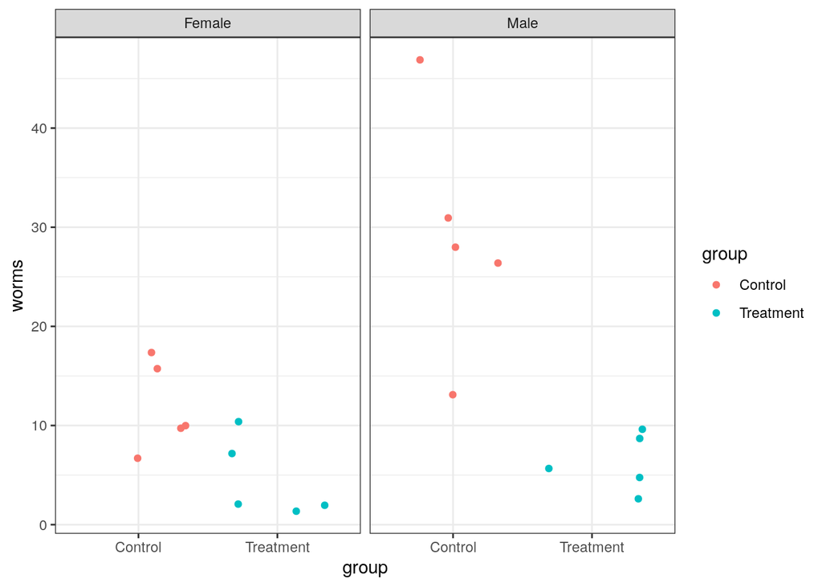

From the graph above, we can visibly see that for males in the control group, the number of worms is significantly higher per mouse than for females. The data point above 45 worms seems to be an outlier of the data. Using R, we can create a numerical summary for the mice based on gender and control v. treatment groups. We can sort all of the data first by gender, and then by respective group to get an understanding for each of the four groups.

```
##    gender     group worms
## 1  Female   Control     7
## 2  Female   Control    10
## 3  Female   Control    10
## 4  Female   Control    16
## 5  Female   Control    17
## 6  Female Treatment     1
## 7  Female Treatment     2
## 8  Female Treatment     2
## 9  Female Treatment     7
## 10 Female Treatment    10
## 11   Male   Control    13
## 12   Male   Control    26
## 13   Male   Control    28
## 14   Male   Control    31
## 15   Male   Control    47
## 16   Male Treatment     3
## 17   Male Treatment     5
## 18   Male Treatment     6
## 19   Male Treatment     9
## 20   Male Treatment    10
```

From here, we can summarize the data with a numerical summary.

```
## # A tibble: 4 x 6
## # Groups:   gender [2]
##   gender group        Md  Mean    SD     N
##   <fct>  <fct>     <dbl> <dbl> <dbl> <int>
## 1 Female Control      10  12    4.30     5
## 2 Female Treatment     2   4.4  3.91     5
## 3 Male   Control      28  29   12.2      5
## 4 Male   Treatment     6   6.6  2.88     5
```

K11777 appears to have reduced the number of parasite worms in this sample. But descriptive statistics are usually only the first step in ascertaining whether an effect is real; we often conduct a significance test or create a confidence interval to determine if chance alone could explain the effect.

## Statistical Inference Through a Randomization Test

- $H_0$: the treatment has no effect on the average worm count
- $H_A$: the treatment decreases the average worm count

## Conducting a Randomization Test by Hand

If we wrote each of the female worm counts out by hand on individual index cards, shuffled them, and drew 5 cards (without replacement), we would’ve randomly selected the treatment group for this experiment. The remaining 5 cards would be the control group. The results of this are shown below.

```r
#-----------------------------------#
# Drawing 10 index cards at random,
# reassign the 'treatment' and 'control' groups
#-----------------------------------#
treatment <- c(2,7,7,16,17)
control <- c(1,2,10,10,10)

# Find the difference of the means
mean(treatment)
```

```
## [1] 9.8
```

```r
mean(control)
```

```
## [1] 6.6
```

```r
mean(treatment) - mean(control)
```

```
## [1] 3.2
```

## Performing a Randomization Test Using Computer Simulation

While this is a good excercise to do once or twice, it is impractical to use this method for random selection over and over again. We could write a program to simulate this event over and over again, instead of doing this by hand each time. This function randomizes the groups 10,000 times, and then creates a boxplot of $\Delta \mu$.

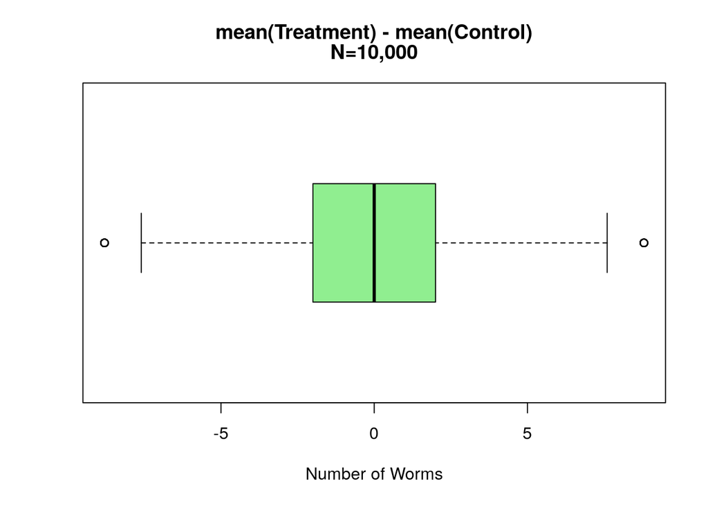

As it can be seen in the boxplot, there is a large possibility for the value of $\Delta \mu$, so you would not get the same result every time, as the odds of each group having the same mean each simulation is very low. As it can be seen in the boxplot, there are very few times where $\Delta \mu > 7.6$. Below is the ratio, $\frac{\# \Delta \mu > 7.6}{N=10,000}$

```
## [1] 0.0038
```

## Two-Sample Permutation Test

- Pool the m + n values. **repeat**
- Draw a resample of size m without replacement.
- Use the remaining n observations for the other sample.
- Calculate the difference in means or another test statistic that compares samples.

**until**

- we have enough samples

Calculate the p-value as the fraction of times the random statistics are more or as extreme as the original statistic. Optionally, plot a histogram of the random statistic values.

## Using Computer Simulations to Conduct a Hypothesis Test

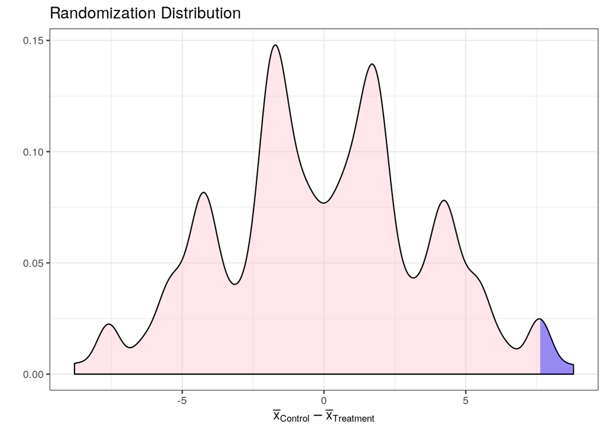

```r
ND2 <- schis %>%
  filter(gender == "Female")

ANS1 <- with(data = ND2,
             tapply(worms, group, mean)
             )
observed <- ANS1[1] - ANS1[2]

N <- 10^4 - 1          # number of times to repeat the process
result2 <- numeric(N)  # space to save the random differences
set.seed(5)
for (i in 1:N){
  # sample of size 5, from 1 to 10, without replacement
  index <- sample(10, size = 5, replace = FALSE)
  result2[i] <- mean(ND2$worms[index]) - mean(ND2$worms[-index])
}
# Graph Now
# ggplot2 approach now
DF <- data.frame(x = result2)
p <- ggplot(data = DF) + geom_density(aes(x = x, y = ..density..), fill = 'pink', alpha = 0.4) +
  theme_bw()

x.dens <- density(result2)
df.dens <- data.frame(x = x.dens$x, y = x.dens$y)
p + geom_area(data = subset(df.dens, x >= 7.6 & x <= max(DF$x)), aes(x = x, y = y), fill = 'blue', alpha = 0.4) +
  labs(x = expression(bar(x)[Control] - bar(x)[Treatment]), y = '', title = "Randomization Distribution") +
  theme_bw()
```

```r
pvalue <- (sum(result2 >= observed) + 1)/(N + 1) # p-value
pvalue  # results will vary
```

```
## [1] 0.0304
```

## A two-sided Hypothesis Test

- $H_0$: the treatment has no effect on the average worm count
- $H_A$: the treatment affects the average worm count

This means we run the same simulations as in the previous section, but we take the absolute value of the value $\Delta \mu$.

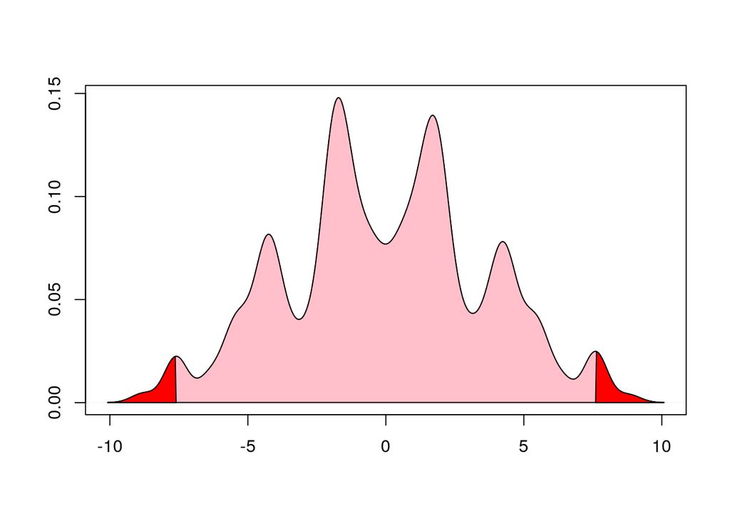

```r
d.res <- density(result2)
plot(d.res, main ="", xlab = "", ylab = "")
polygon(d.res, col ="pink")
xsr <- c(7.6, d.res$x[d.res$x >= 7.6])
ysr <- c(0, d.res$y[d.res$x>=7.6])
xsl <- c(-7.6, d.res$x[d.res$x <= -7.6])
ysl <- c(0, d.res$y[d.res$x <= -7.6])
polygon(xsr, ysr, col = "red")
polygon(xsl, ysl, col = "red")
```

```r
pvalue <- (sum(result2 >= observed) + sum(result2 <= -observed) + 1)/(N + 1) # p-value
pvalue  # results will vary
```

```
## [1] 0.0588
```

As expected, the p-value is nerely doubled in this scenario, which shouldn’t be surprising as the distribution is almost reflected over the line $x=0$, so there is nearly a $2x$ chance of finding a value $|\Delta \mu| >7.6$ compared to $\Delta \mu > 7.6$.